# PSTAT231 Homework 2

Olivia Quinn

April 10, 2022

Relevant packages:

```r
library(tidyverse)
library(tidymodels)
library(readr)
```

Data:

```r
abalone <- read_csv("data/abalone.csv")
head(abalone)
```

```
## # A tibble: 6 × 9
##   type  longest_shell diameter height whole_weight shucked_weight viscera_weight
##   <chr>         <dbl>    <dbl>  <dbl>        <dbl>          <dbl>          <dbl>
## 1 M             0.455    0.365  0.095        0.514         0.224          0.101
## 2 M             0.35     0.265  0.09         0.226         0.0995         0.0485
## 3 F             0.53     0.42   0.135        0.677         0.256          0.142
## 4 M             0.44     0.365  0.125        0.516         0.216          0.114
## 5 I             0.33     0.255  0.08         0.205         0.0895         0.0395
## 6 I             0.425    0.3    0.095        0.352         0.141          0.0775
## # … with 2 more variables: shell_weight <dbl>, rings <dbl>
```

## Linear Regression

#### Question 1: Abalone Age

Abalone age ranges from 2.5 to 30.5 years. The median age is 10.5 years. The histogram shows a bit of a right skew, indicating that a few abalones grow to be much older than others.

```r
# create age variable
abalone <- abalone %>%
  mutate(age = rings + 1.5)

# assess and describe the distribution of 'age'
summary(abalone)
```

```
##      type           longest_shell      diameter          height
##  Length:4177        Min.   :0.075   Min.   :0.0550   Min.   :0.0000
##  Class :character   1st Qu.:0.450   1st Qu.:0.3500   1st Qu.:0.1150
##  Mode  :character   Median :0.545   Median :0.4250   Median :0.1400
##                     Mean   :0.524   Mean   :0.4079   Mean   :0.1395
##                     3rd Qu.:0.615   3rd Qu.:0.4800   3rd Qu.:0.1650
##                     Max.   :0.815   Max.   :0.6500   Max.   :1.1300
##   whole_weight    shucked_weight   viscera_weight    shell_weight
##  Min.   :0.0020   Min.   :0.0010   Min.   :0.0005   Min.   :0.0015
##  1st Qu.:0.4415   1st Qu.:0.1860   1st Qu.:0.0935   1st Qu.:0.1300
##  Median :0.7995   Median :0.3360   Median :0.1710   Median :0.2340
##  Mean   :0.8287   Mean   :0.3594   Mean   :0.1806   Mean   :0.2388
##  3rd Qu.:1.1530   3rd Qu.:0.5020   3rd Qu.:0.2530   3rd Qu.:0.3290
##  Max.   :2.8255   Max.   :1.4880   Max.   :0.7600   Max.   :1.0050
##      rings             age
##  Min.   : 1.000   Min.   : 2.50
##  1st Qu.: 8.000   1st Qu.: 9.50
##  Median : 9.000   Median :10.50
##  Mean   : 9.934   Mean   :11.43
##  3rd Qu.:11.000   3rd Qu.:12.50
##  Max.   :29.000   Max.   :30.50
```

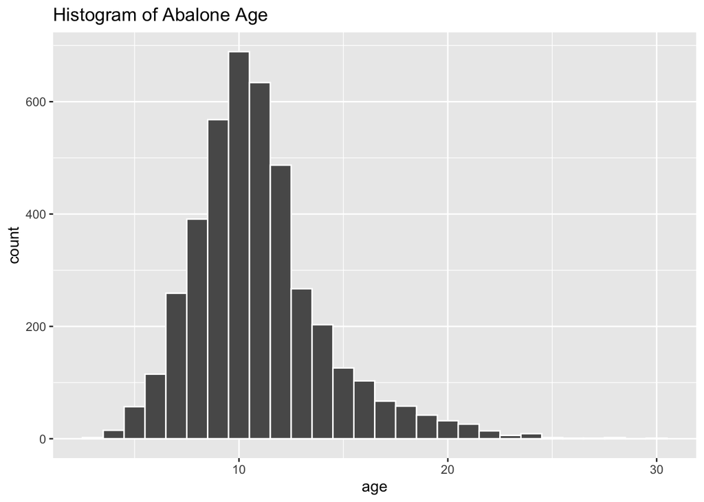

```r
ggplot(abalone, aes(age)) +
  geom_histogram(binwidth=1, color = "white") +
  labs(title= "Histogram of Abalone Age")
```

#### Question 2: Split data into training and testing set

```r
set.seed(24)

abalone_split <- initial_split(abalone, prop = 0.80,
                                strata = age)
abalone_train <- training(abalone_split)
abalone_test <- testing(abalone_split)
```

#### Question 3: Create a recipe predicting age (+ why you shouldn’t use rings to predict age)

1. dummy code “type”
2. create interactions between
   - `type` and `shucked_weight`,
   - `longest_shell` and `diameter`,
   - `shucked_weight` and `shell_weight`
3. center all predictors, and
4. scale all predictors.

*Note: We don’t want to use “rings” because it correlates perfectly with our outcome “age”.

```r
abalone_recipe <- recipe(age ~ type + longest_shell + diameter + height + whole_weight + shucked_weight + viscera_weight + shell_weight, data = abalone_train) %>%
  step_dummy(all_nominal_predictors()) %>%
  step_interact(terms = ~ shucked_weight:starts_with("type")) %>%
  step_interact(terms = ~ longest_shell:diameter) %>%
  step_interact(terms = ~ shucked_weight:shell_weight) %>%
  step_normalize(all_predictors())

#new set of predictors - rings.
summary(abalone_recipe)
```

```
## # A tibble: 9 × 4
##   variable       type    role      source
##   <chr>          <chr>   <chr>     <chr>
## 1 type           nominal predictor original
## 2 longest_shell  numeric predictor original
## 3 diameter       numeric predictor original
## 4 height         numeric predictor original
## 5 whole_weight   numeric predictor original
## 6 shucked_weight numeric predictor original
## 7 viscera_weight numeric predictor original
## 8 shell_weight   numeric predictor original
## 9 age            numeric outcome   original
```

#### 4. Create and store linear regression object

```r
lm_model <- linear_reg() %>%
  set_engine("lm")
```

#### 5. Workflow + model + recipe

```r
lm_workflow <- workflow() %>%
  add_model(lm_model) %>%
  add_recipe(abalone_recipe)
```

#### 6. Predict the age of a hypothetical female abalone with longest_shell = 0.50, diameter = 0.10, height = 0.30, whole_weight = 4, shucked_weight = 1, viscera_weight = 2, shell_weight = 1.

```r
#fit the model to the training set
lm_fit <- fit(lm_workflow, abalone_train)
lm_fit %>%
  extract_fit_parsnip() %>%
  tidy()
```

```
## # A tibble: 14 × 5
##    term                          estimate std.error statistic  p.value
##    <chr>                            <dbl>     <dbl>     <dbl>    <dbl>
##  1 (Intercept)                     11.4      0.0373   307.    0
##  2 longest_shell                    0.410    0.285      1.44  1.51e- 1
##  3 diameter                         2.34     0.311      7.52  7.21e-14
##  4 height                           0.227    0.0698     3.26  1.15e- 3
##  5 whole_weight                     4.99     0.406     12.3   5.44e-34
##  6 shucked_weight                  -4.30     0.255    -16.9   1.74e-61
##  7 viscera_weight                  -0.878    0.159     -5.53  3.44e- 8
##  8 shell_weight                     1.64     0.220      7.44  1.26e-13
##  9 type_I                          -0.986    0.114     -8.65  7.68e-18
## 10 type_M                          -0.316    0.102     -3.10  1.97e- 3
## 11 shucked_weight_x_type_I          0.549    0.0862     6.37  2.09e-10
## 12 shucked_weight_x_type_M          0.364    0.107      3.41  6.53e- 4
## 13 longest_shell_x_diameter        -3.04     0.400     -7.61  3.57e-14
## 14 shucked_weight_x_shell_weight   -0.120    0.202     -0.593 5.53e- 1
```

```r
#predicted age of hypothetical female outlined above : 24.23 years old

female <- data.frame(type = "F", longest_shell = 0.50, diameter = 0.10, height = 0.30, whole_weight = 4, shucked_weight = 1, viscera_weight = 2, shell_weight = 1)

predict(lm_fit, new_data = female)
```

```
## # A tibble: 1 × 1
##   .pred
##   <dbl>
## 1  24.2
```

#### 7. Assess Model Performance

```r
#create tibble of predicted and observed values for "age" in the training set
abalone_train_res <- predict(lm_fit, new_data = abalone_train %>% select(-age))
abalone_train_res <- bind_cols(abalone_train_res, abalone_train %>% select(age))

abalone_train_res %>%
  head()
```

```
## # A tibble: 6 × 2
##   .pred   age
##   <dbl> <dbl>
## 1  9.47   8.5
## 2  9.34   9.5
## 3  9.78   8.5
## 4 10.4    8.5
## 5 11.0    9.5
## 6  6.29   6.5
```

The metrics for this linear model:

- RMSE = 2.15
- $R^2$ = 0.56
- MAE = 1.55

The $R^2$ of this model is good, but underwhelming. The various predictors acting together (and not including rings) predict 56% of the variation in age. If number of rings predicts *more* of the variation in age, it might still be worth cracking them open to get a more accurate measure of age.

```r
abalone_metrics <- metric_set(rmse, rsq, mae)
abalone_metrics(abalone_train_res, truth = age,
                estimate = .pred)
```

```
## # A tibble: 3 × 3
##   .metric .estimator .estimate
##   <chr>   <chr>          <dbl>
## 1 rmse    standard       2.15
## 2 rsq     standard       0.562
## 3 mae     standard       1.55
```

#### 231 Questions

#### Question 8: Which term(s) in the bias-variance tradeoff above represent the reproducible error? Which term(s) represent the irreducible error?

$var(\hat{f}(x_0))+[bias(\hat{f}(x_0))]^2$ represent the reducible error.

$var(\epsilon)$ represents the irreducible error.

#### Question 9: Using the bias-variance tradeoff above, demonstrate that the expected test error is always at least as large as the irreducible error.

$$E[(y_0 - \hat{f}(x_0))^2]=var(\hat{f}(x_0))+[bias(\hat{f}(x_0))]^2+var(\epsilon)$$
Under the “best we can do” assumption where the outcome of our modeled function $\hat{f}(x_0)$ is equal to the “true” expectation of $Y$:

$$\hat{f}(x_0) = E[{Y}|{X} = x_0]$$
We can assume that the first right-hand term is equivalent to

$var(\hat{f}(x_0)) = var(E[{Y}|{X} = x_0]) = 0$,

and the second right-hand term is equivalent to

$[bias(\hat{f}(x_0))]^2 = [bias(E[{Y}|{X} = x_0]))^2 = 0$,

leaving only

$= 0 + 0 + var(\epsilon)$

#### Question 10: Prove the bias-variance tradeoff.

Starting with the test MSE and the assumption (from above) that $y=f(x) + \epsilon$:

$E[(y_0-\hat{f}(x_0))^2] = E[(f(x_0) + \epsilon - \hat{f}(x_0))^2]$

$=E[(f(x_0) - \hat{f}(x_0))^2] + E[\epsilon^2] + 2E[({f}(x_0) -\hat{f}(x_0))\epsilon]$

$=E[(f(x_0) - \hat{f}(x_0))^2] + E[\epsilon^2] + 2E[({f}(x_0) -\hat{f}(x_0))] E[\epsilon]$

$=E[(f(x_0) - \hat{f}(x_0))^2] + Var(\epsilon)$ **(solution 1)**

**Now, starting with the reducible error:**

$E[(f(x_0) - \hat{f}(x_0))^2] = E[((f(x_0) - E[\hat{f}(x_0)]) - (\hat{f}(x_0) -E[\hat{f}(x_0)]))^2]$

$= E[(E[\hat{f}(x_0)] - f(x_0))^2] + E[(\hat{f}(x_0) - E[\hat{f}(x_0)]^2] - 2E[(f(x_0) - E[\hat{f}(x_0)])(\hat{f}(x_0) -E[\hat{f}(x_0)])$

$= (E[\hat{f}(x_0)] - f(x_0))^2 + E[(\hat{f}(x_0) - E[\hat{f}(x_0)])^2] - 2(f(x_0) - E[\hat{f}(x_0)] E[(\hat{f}(x_0)-E[\hat{f}(x_0)])]$

$= bias[\hat{f}(x_0)]^2 + var(\hat{f}(x_0)) - 2(f(x_0) - E[\hat{f}(x_0)]) (E[\hat{f}(x_0)] - E[\hat{f}(x_0)])$

$= bias[\hat{f}(x_0)]^2 + var(\hat{f}(x_0))$ **(solution 2)**

**Combining solutions 1 and 2:**

$E[(y-\hat{f}(x_0))^2] = bias[\hat{f}(x_0)]^2 + var(\hat{f}(x_0)) + var(\epsilon)$